# Stats Notebook

### Data cleaning and preparation

```r
clean_beds <- read_csv("raw_data/beds_specialty.csv") %>%
  clean_names() %>%
  filter(location_qf == "d") %>%
  mutate(year = year(yq(quarter)),
         quarter = str_sub(quarter, -2),
         winter_flag = if_else(
           quarter %in% c("Q1", "Q4"), "Winter", "Summer")) %>%
  select(year, winter_flag, hb, specialty_name, percentage_occupancy) %>%
  group_by(winter_flag, year, hb) %>%
  summarise(percentage_occupancy = mean(percentage_occupancy)) %>%
  mutate(hb_name = case_when(
    hb == "S92000003" ~ "Scotland",
    hb == "S08000015" ~ "Ayrshire and Arran",
    hb == "S08000016" ~ "Borders",
    hb == "S08000017" ~ "Dumfries and Galloway",
    hb == "S08000019" ~ "Forth Valley",
    hb == "S08000020" ~ "Grampian",
    hb == "S08000022" ~ "Highland",
    hb == "S08000024" ~ "Lothian",
    hb == "S08000025" ~ "Orkney",
    hb == "S08000026" ~ "Shetland",
    hb == "S08000028" ~ "Western Isles",
    hb == "S08000029" ~ "Fife",
    hb == "S08000030" ~ "Tayside",
    hb == "S08000031" ~ "Greater Glasgow and Clyde",
    hb == "S08000032" ~ "Lanarkshire",
    TRUE ~ as.character(NA))) %>%
  filter(!is.na(hb_name)) %>%
  rename(hb_code = hb)
clean_beds
```

| winter_flag | year | hb_code | percentage_occupancy | hb_name |
| --- | --- | --- | --- | --- |
| Summer | 2016 | S08000015 | 82.38905 | Ayrshire and Arran |
| Summer | 2016 | S08000016 | 80.09952 | Borders |
| Summer | 2016 | S08000017 | 67.87571 | Dumfries and Galloway |
| Summer | 2016 | S08000019 | 87.21690 | Forth Valley |
| Summer | 2016 | S08000020 | 76.89589 | Grampian |
| Summer | 2016 | S08000022 | 74.62679 | Highland |
| Summer | 2016 | S08000024 | 78.09763 | Lothian |
| Summer | 2016 | S08000025 | 79.31602 | Orkney |
| Summer | 2016 | S08000026 | 69.92235 | Shetland |
| Summer | 2016 | S08000028 | 62.74050 | Western Isles |

[output cut: 170 more lines]

#### Calculate mean percentage occupancy across Scotland for winter (Q1, Q4) and summer (Q2, Q3) months.

```r
wint_av <- clean_beds %>%
  filter(hb_name == "Scotland", winter_flag == "Winter") %>%
  group_by(winter_flag) %>%
  summarise(av_occupancy = mean(percentage_occupancy)) %>% pull()

summer_av <- clean_beds %>%
  filter(hb_name == "Scotland", winter_flag == "Summer") %>%
  group_by(winter_flag) %>%
  summarise(av_occupancy = mean(percentage_occupancy)) %>% pull()

# The difference of averages
obs_stat = wint_av - summer_av

wint_av
```

```
## [1] 72.50597
```

```r
summer_av
```

```
## [1] 70.65544
```

```r
obs_stat
```

```
## [1] 1.850536
```

### Statistical Analysis

#### Confidence intervals

Let us visualise the confidence intervals if we bootsrap the average values of occupancy for winter and summer.

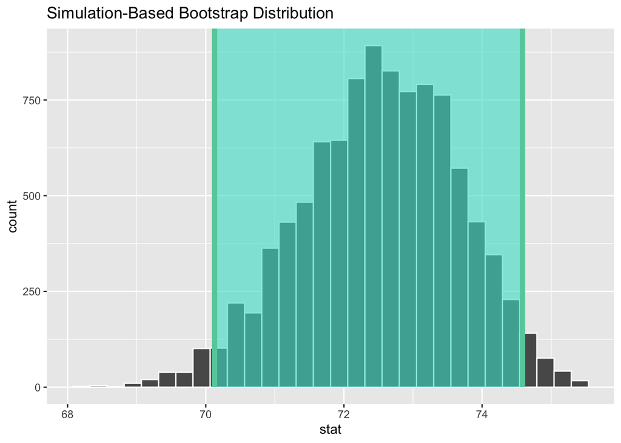

```r
# All of Scotland, winter quarters
occupancy_resample <- clean_beds %>%
  filter(hb_code == "S92000003", winter_flag == "Winter") %>%
  specify(response = percentage_occupancy) %>%
  generate(reps = 10000, type = "bootstrap") %>%
  calculate(stat = "mean")

occupancy_ci <- occupancy_resample %>%
  get_confidence_interval(level = 0.95, type = "percentile")

occupancy_resample %>%
  visualise(bins = 30) +
  shade_confidence_interval(endpoints = occupancy_ci)
```

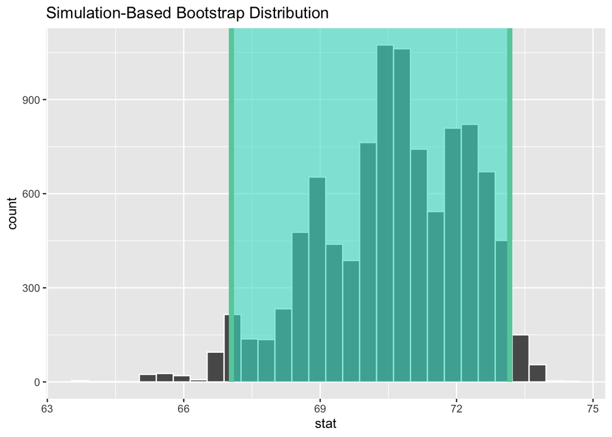

```r
# All of Scotland, summer quarters
occupancy_resample <- clean_beds %>%
  filter(hb_code == "S92000003", winter_flag == "Summer") %>%
  specify(response = percentage_occupancy) %>%
  generate(reps = 10000, type = "bootstrap") %>%
  calculate(stat = "mean")

occupancy_ci <- occupancy_resample %>%
  get_confidence_interval(level = 0.95, type = "percentile")

occupancy_resample %>%
  visualise(bins = 30) +
  shade_confidence_interval(endpoints = occupancy_ci)
```

#### Hypothesis: bed occupancy is greater in winter.

The difference in average occupancy between winter and summer seems statistically significant. Let us generate a null distribution via permutation. $H_0$ is that the difference in average occupancy is **not** statistically significant. Assume that $\alpha = 0.05$ i.e. we will take the result as showing that the difference is statistically significant if the found $p$ value is smaller than $\alpha$.

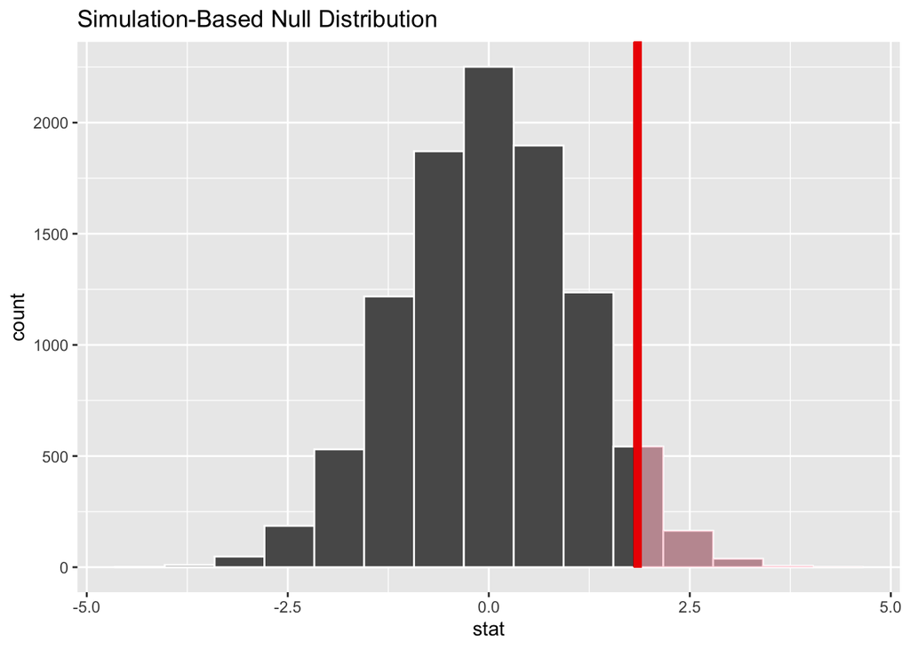

```r
clean_beds %>%
  specify(percentage_occupancy ~ winter_flag) %>%
  hypothesise(null = "independence") %>%
  generate(reps = 10000, type = "permute") %>%
  calculate(stat = "diff in means", order = c("Winter", "Summer")) %>%
  visualise() +
  shade_pvalue(obs_stat = obs_stat, direction =  "right")
```

```r
clean_beds %>%
  specify(percentage_occupancy ~ winter_flag) %>%
  hypothesise(null = "independence") %>%
  generate(reps = 10000, type = "permute") %>%
  calculate(stat = "diff in means", order = c("Winter", "Summer")) %>%
  get_pvalue(obs_stat = obs_stat, direction =  "right")
```

| p_value |
| --- |
| 0.0427 |

### Interpretation of analyis

As the $p$ value is smaller than the established significance value $\alpha$ we reject $H_0$ to conclude that the difference in average bed occupancy between winter and summer in Scotland is statistically significant.

# A&E Attendance data preparation

Let us look at the number of people waiting in A&E for longer than 8 hours.

```r
clean_ae <-read_csv("clean_data/clean_ae.csv")
```

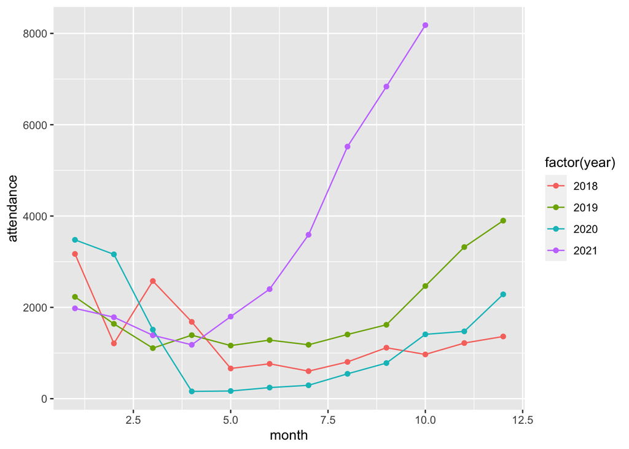

```r
clean_ae %>%
  filter(year > 2017) %>%
  group_by(month, year) %>%
  summarise(attendance = sum(attendance_greater8hrs, na.rm = T)) %>%
  ggplot(aes(month, attendance, fill = factor(year), col = factor(year))) +
  geom_point() +
  geom_line()
```

```r
ae_stats <- clean_ae %>%
  filter(year > 2007, department_type == "Emergency Department") %>%
  group_by(month, year) %>%
  summarise(attendance = sum(attendance_greater8hrs, na.rm = T)) %>%
  # Create a winter flag
  mutate(winter_flag = case_when(month %in% c(1, 2, 3, 10, 11, 12) ~ "Winter",
                            TRUE ~ "Summer")) %>%
  group_by(winter_flag, year) %>%
  summarise(av_attendance = mean(attendance)) %>%
  arrange(year)
ae_stats
```

| winter_flag | year | av_attendance |
| --- | --- | --- |
| Summer | 2008 | 136.5000 |
| Winter | 2008 | 215.8333 |
| Summer | 2009 | 124.6667 |
| Winter | 2009 | 203.5000 |
| Summer | 2010 | 165.5000 |
| Winter | 2010 | 370.3333 |
| Summer | 2011 | 291.0000 |
| Winter | 2011 | 531.5000 |
| Summer | 2012 | 398.6667 |
| Winter | 2012 | 762.6667 |

[output cut: 18 more lines]

### Exploratory analysis

It seems that average A&E attendance is greater in the winter. It also seems that it is increasing.

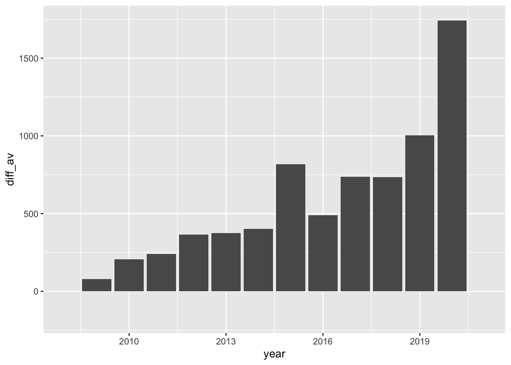

```r
ae_stats %>%
  mutate(av_attendance = if_else(
    winter_flag == "Summer", -av_attendance, av_attendance)) %>%
  group_by(year) %>%
  summarise(diff_av = sum(av_attendance)) %>%
  ggplot(aes(year, diff_av)) +
  geom_col() +
  xlim(2008, 2021)
```

The amount of people that wait in A&E longer than 8 hrs is greater every winter compared to the respective summer.